# Functions

10/22/2019

### To understand computations in R, two slogans are helpful:

### - Everything that exists is an object.

### - Everything that happens is a function call.

### **John Chambers**

## Motivation

Imagine you’ve loaded a data file, like the one below, that uses `−99` to represent missing values. You want to replace all the `−99`s with `NA`s.

```r
set.seed(1014)
df <- data.frame(replicate(6, sample(c(1:10, -99), 6, rep = TRUE)))
names(df) <- letters[1:6]
df
```

```
##   a   b   c   d  e f
## 1 7   5 -99   2  5 2
## 2 5   5   5   3  6 1
## 3 6   8   5   9  9 4
## 4 4   2   2   6  6 8
## 5 6   7   6 -99 10 6
## 6 9 -99   4   7  5 1
```

## Motivation

When you first started writing R code, you might have solved the problem with copy-and-paste:

```r
df$a[df$a == -99] <- NA
df$b[df$b == -99] <- NA
df$c[df$c == -98] <- NA
df$d[df$d == -99] <- NA
df$e[df$e == -99] <- NA
df$f[df$g == -99] <- NA
```

One problem with copy-and-paste is that it’s easy to make mistakes.

To prevent bugs and to make more flexible code, adopt the **“do not repeat yourself”**, or DRY, principle.

## Motivation

Define a function:

```r
fix_missing <- function(x) {
  x[x == -99] <- NA
  x
}

df[] <- lapply(df, fix_missing)
```

## Motivation

What if different columns used different codes for missing values? You might be tempted to copy-and-paste:

```r
fix_missing_99 <- function(x) {
  x[x == -99] <- NA
  x
}
fix_missing_999 <- function(x) {
  x[x == -999] <- NA
  x
}
fix_missing_9999 <- function(x) {
  x[x == -999] <- NA
  x
}
```

## Motivation

In this case, it is possible to use an extra argument:

```r
fix_missing <- function(x, na.value) {
  x[x == na.value] <- NA
  x
}
```

## Introduction

A **function** is a set of R expressions organized together to perform a specific task. Using functions allows dramatically decrease the amount of duplicated code.

The function in R can take arguments, modify and return objects. Functions are very similar to mathematical concept: get an input, do something inside, return an output.

R has a large number of in-built functions and the user can create their own functions. An R function is created by using the keyword `function`.

```r
function_name <- function(arg1, arg2) {
  body of the function
}
```

The last expression evaluated in a function becomes the return value, the result of invoking the function.

## Introduction

Example:

```r
square <- function(x) {
  x ^ 2
}
square(5)
```

```
## [1] 25
```

## Introduction

Example:

```r
capitalize <- function(x) {
  i <- sample(1:nchar(x), size = 1)
  substr(x = x, start = i, stop = i) <-
    toupper(substr(x = x, start = i, stop = i))
  x
}
capitalize("someletters")
```

```
## [1] "somelEtters"
```

## Function components

- the `body()`, the code inside the function.
- the `formals()`, the list of arguments which controls how you can call the function.
- the `environment()`, the “map” of the location of the function’s variables.

## Function components

```r
f <- function(arg) arg^2
formals(f)
```

[output not shown]

```r
body(f)
```

```
## arg^2
```

```r
environment(f)
```

```
## <environment: R_GlobalEnv>
```

## Primitive functions

There is one exception to the rule that functions have three components. Primitive functions, like `sum()`, call C code directly with `.Primitive()` and contain no R code. Therefore their `formals()`, `body()`, and `environment()` are all NULL.

Primitive functions are only found in the base package (one can use `names(methods:::.BasicFunsList)` to get names of all primitive functions).

## Lexical scoping

Scoping is the set of rules that govern how R looks up the value of a symbol. R has two types of scoping:

- **lexical scoping** (implemented automatically at the language level):
  - name masking
  - functions vs. variables
  - a fresh start
  - dynamic lookup
- dynamic scoping (used in select functions to save typing during interactive analysis, NSE)

Lexical scoping looks up symbol values based on how functions were nested when they were created, not how they are nested when they are called (look at the function’s definition).

## Lexical scoping: name masking

```r
f <- function() {
  x <- 1
  y <- 2
  c(x, y)
}
f()
```

```
## [1] 1 2
```

```r
rm(f)
```

## Lexical scoping: name masking

```r
x <- 10
f <- function() {
  x <- 1
  y <- 2
  c(x, y)
}
f()
```

```
## [1] 1 2
```

```r
rm(f)
```

## Lexical scoping: name masking

If a name isn’t defined inside a function, R will look one level up.

```r
x <- 2
g <- function() {
  y <- 1
  c(x, y)
}
g()
```

```
## [1] 2 1
```

```r
rm(x, g)
```

## Lexical scoping: name masking

The same rules apply if a function is defined inside another function (nested functions):

```r
x <- 1
h <- function() {
  y <- 2
  i <- function() {
    z <- 3
    c(x, y, z)
  }
  i()
}
h()
```

```
## [1] 1 2 3
```

```r
rm(x, h)
```

## Lexical scoping: functions vs. variables

The same principles apply regardless of the type of associated value - finding functions works exactly the same way as finding variables:

```r
l <- function(x) x + 1
m <- function() {
  l <- function(x) x * 2
  l(10)
}
m()
```

```
## [1] 20
```

```r
rm(l, m)
```

## Lexical scoping: functions vs. variables

If you are using a name in a context where it’s obvious that you want a function (e.g., `f(3)`), R will ignore objects that are not functions while it is searching.

```r
n <- function(x) x / 2
o <- function() {
  n <- 10
  n(n)
}
o()
```

```
## [1] 5
```

```r
rm(n, o)
```

Do not do this: too confusing!

## Lexical scoping: a fresh start

Every time a function is called, a new environment is created to host execution. A function has no way to tell what happened the last time it was run; each invocation is completely independent.

```r
j <- function() {
  if (!exists("a")) a <- 1 else a <- a + 1
  a
}
j()
```

```
## [1] 1
```

```r
j()
```

```
## [1] 1
```

## Lexical scoping: dynamic lookup

R looks for values when the function is run, not when it’s created. This means that the output of a function can be different depending on objects outside its environment:

```r
f <- function() x
x <- 15
f()
```

```
## [1] 15
```

```r
x <- 20
f()
```

```
## [1] 20
```

You generally want to avoid this behaviour because it means the function is no longer self-contained.

## Function arguments

Arguments of the function:

- the formal arguments (a property of the function)
- the calling arguments (can vary each time you call the function)

```r
f <- function(y) c(y, x)
x <- 20
f(5)
```

```
## [1]  5 20
```

```r
x <- 15
f(5)
```

```
## [1]  5 15
```

## Function arguments: calling functions

One can specify formal arguments:

- by position
- by complete name
- by partial name

Arguments are matched first by exact name (perfect matching), then by prefix matching, and finally by position.

## Function arguments: calling functions

```r
f <- function(first, second, third) c(first, second, third)
f(5, 6, 10)
```

```
## [1]  5  6 10
```

```r
f(6, 10, first = 5)
```

```
## [1]  5  6 10
```

```r
f(10, t = 6, f = 5)
```

```
## [1]  5 10  6
```

## Function arguments: calling functions

- Positional matching: for the first one or two arguments
- Named arguments should always come after unnamed arguments
- `...`: you can only specify arguments listed after `...` with their full name
- CRAN package: you can **not** use partial matching, only complete names

## Function arguments: calling a function given a list of arguments

Suppose you had a list of function arguments. If one needs to send that list to `mean()`, it is possible to use `do.call()`:

```r
args <- list(1:10, na.rm = TRUE)
do.call(mean, args)
```

```
## [1] 5.5
```

```r
# Equivalent to
mean(1:10, na.rm = TRUE)
```

```
## [1] 5.5
```

## Function arguments: default arguments

Function arguments in R can have default values.

```r
f <- function(a = 1, b = 2) {
  c(a, b)
}
f()
```

```
## [1] 1 2
```

## Function arguments: default arguments

The default value can be defined in terms of other arguments:

```r
g <- function(a = 1, b = a * 2) {
  c(a, b)
}
g()
```

```
## [1] 1 2
```

```r
g(10)
```

```
## [1] 10 20
```

## Function arguments: default arguments

Default arguments can even be defined in terms of variables created within the function (bad practice, read code to guess default value).

```r
h <- function(a = 1, b = d) {
  d <- (a + 1) ^ 2
  c(a, b)
}
h()
```

```
## [1] 1 4
```

```r
h(10)
```

```
## [1]  10 121
```

## Function arguments: missing arguments

You can determine if an argument was supplied or not with the `missing()` function.

```r
i <- function(a, b) {
  c(missing(a), missing(b))
}
i()
```

```
## [1] TRUE TRUE
```

```r
i(a = 1)
```

```
## [1] FALSE  TRUE
```

## Function arguments: missing arguments

Sometimes you want to add a non-trivial default value, which might take several lines of code to compute. Instead of inserting that code in the function definition, you could use `missing()` to conditionally compute it if needed.

However, this makes it hard to know which arguments are required and which are optional without carefully reading the documentation. Instead, the default value can be set to `NULL` and `is.null()` is used to check if the argument was supplied.

## Function arguments: `match.arg`

`match.arg` matches `arg` against a table of candidate values as specified by choices, where `NULL` means to take the first one.

```r
center <- function(x, type = c("mean", "median", "trimmed")) {
  type <- match.arg(type)
  switch(type,
         mean = mean(x),
         median = median(x),
         trimmed = mean(x, trim = .1))
}
```

## Function arguments: Lazy evaluation

By default, R function arguments are lazy — they’re only evaluated if they’re actually used:

```r
f <- function(x) {
  10
}
f(stop("This is an error!"))
```

```
## [1] 10
```

## Function arguments: Lazy evaluation

If you want to ensure that an argument is evaluated you can use `force()`:

```r
f <- function(x) {
  force(x)
  10
}
f(stop("This is an error!"))
```

```
## Error in force(x): This is an error!
```

## Function arguments: `...`

There is a special argument called `...`. This argument will match any arguments not otherwise matched, and can be easily passed on to other functions. This is useful if you want to collect arguments to call another function, but you don’t want to prespecify their possible names.

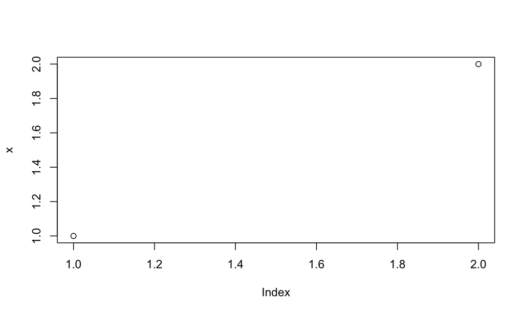

```r
my_plot <- function(x, ...) {
  plot(x, ...)
}
my_plot(c(1, 2))
```

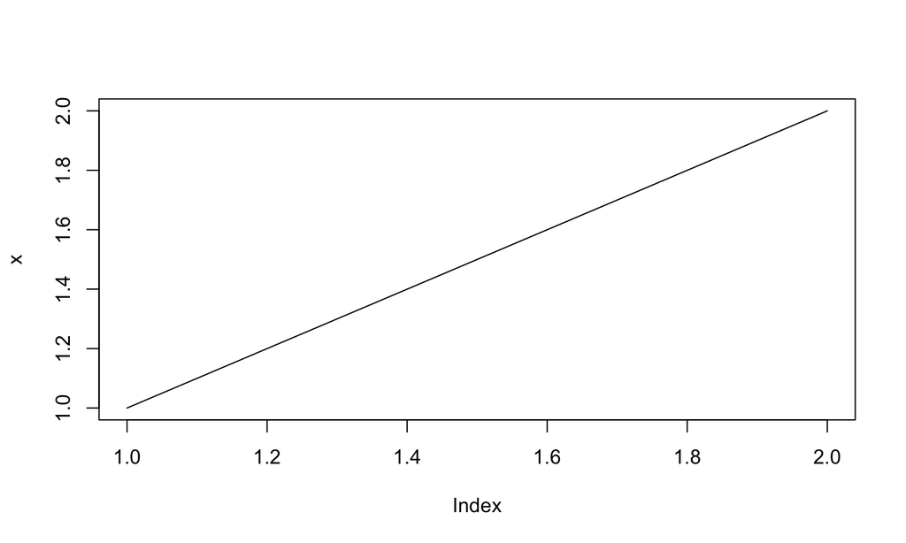

```r
my_plot(c(1, 2), type = "l")
```

## Function arguments: `...`

Less frequently, a function will need to refer to components of `...`. The expression `list(...)` evaluates all such arguments and returns them in a named list, while `..1`, `..2`, etc. evaluate them one at a time, with `..n` returning the n’th unmatched argument.

```r
multiply_by_ten <- function(...) {
  c(...) * 10
}
x <- c(1.1, 2.2, 3.3, NA)
multiply_by_ten(x)
```

```
## [1] 11 22 33 NA
```

```r
multiply_by_ten(16, 23, 31)
```

```
## [1] 160 230 310
```

## Special calls

R supports two additional syntaxes for calling special types of functions: infix and replacement functions. Both of them are nothing else than a syntactic sugar for an ordinary function call.

## Special calls: Infix functions

### …

### - Everything that happens is a function call.

### **John Chambers**

Every operation in R is a function call, whether or not it looks like one. This includes infix operators like `+`, control flow operators like `for`, `if`, and `while`, subsetting operators like `[]` and `$`, and even the curly brace `{`.

Note that `, the backtick, lets you refer to functions or variables that have otherwise reserved or illegal names.

## Special calls: Infix functions

```r
x <- 10; y <- 5
x + y
```

```
## [1] 15
```

```r
`+`(x, y)
```

```
## [1] 15
```

```r
for (i in 1:2) print(i)
```

```
## [1] 1
## [1] 2
```

```r
`for`(i, 1:2, print(i))
```

```
## [1] 1
## [1] 2
```

## Special calls: Infix functions

Most functions in R are “prefix” operators: the name of the function comes before the arguments.One can also create infix functions where the function name comes in between its arguments, like `+` or `-`. All user-created infix functions must start and end with `%`.

## Special calls: Infix functions

```r
`%+%` <- function(a, b) paste0(a, b)
"new" %+% " string"
```

```
## [1] "new string"
```

```r
library(magrittr)
rnorm(1000) %>% mean()
```

```
## [1] 0.005064201
```

## Special calls: Replacement functions

Replacement functions:

- act like they modify their arguments in place
- have the special name `xxx<-`.
- typically have two arguments (`x` and `value`)

## Special calls: Replacement functions

```r
`second<-` <- function(x, value) {
  x[2] <- value
  x
}
x <- 1:10
second(x) <- 5L
x
```

```
##  [1]  1  5  3  4  5  6  7  8  9 10
```

Replacement functions “act like they modify their arguments in place”, because they actually create a modified copy.

## Return values

If `return()` function is not specified, the last expression evaluated in a function becomes the return value, the result of invoking the function.

Functions can return only a single object. But this is not a limitation because you can return a list containing any number of objects.

## Other important things

- Pure functions: no side effects
- copy-on-modify semantics: modifying a function argument does not change the original value
- `on.exit()`: triggers to occur when the function is finished

## Anonymous functions

In R, functions are objects in their own right. They aren’t automatically bound to a name. If you choose not to give the function a name, you get an anonymous function.

One use of anonymous functions is to create small functions that are not worth naming.

Most of the time they are used in conjuntion with functional, a function that takes a function as an input and returns a vector as output (e.g., `lapply`):

```r
sapply(mtcars, function(x) length(unique(x)))
```

```
##  mpg  cyl disp   hp drat   wt qsec   vs   am gear carb
##   25    3   27   22   22   29   30    2    2    3    6
```

## Anonymous functions

You can call an anonymous function without giving it a name

```r
(function(x) print(x))(3)
```

```
## [1] 3
```

## Closures

Another important use is to create **closures**, functions written by functions. Closures get their name because they **enclose** the environment of the parent function and can access all its variables.

## Closures

```r
power <- function(exponent) {
  function(x) {
    x ^ exponent
  }
}

square <- power(2)
square(3)
```

```
## [1] 9
```

```r
cube <- power(3)
cube(5)
```

```
## [1] 125
```

## Lists of functions

In R, functions can be stored in lists.

```r
moments <- list(
  first = function(x, ...) mean(x),
  second = function(x, ...) var(x)
)

moments$first(rnorm(100))
```

```
## [1] -0.02582926
```

## References

**Advanced R** by Hadley Wickham